# Homework2

Li Xiangchao

2021-12-16

## HW7

8.2

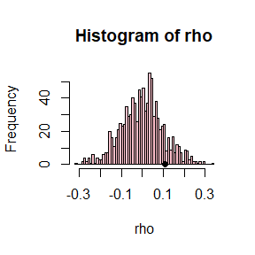

```r
library(mvtnorm)

set.seed(333)
cov_matrix<-diag(c(1,1))
# generate bivariate normal sample (x,y), x ,y are independent.


z<-rmvnorm(100,rep(0,2),cov_matrix)
x<-z[,1]
y<-z[,2]
# Null hypothesis is that x is independent of y.


spear_cor<-cor.test(x,y,method="spearman")
rho_0<-spear_cor$estimate
# correlation coefficient use the method ,spearman.
R<-999
# the number of replicate.

data<-c(x,y)

rho<-numeric(R)
for (r in 1:R) {
  index<-sample(1:200,size=100,replace = FALSE)
  x_1<-data[index]
  y_1<-data[-index]
  rho[r]<-cor(x_1,y_1,method="spearman")
}

# rhohat is correlation coefficient computed by permutation method.
hist(rho,breaks = 50,col="pink")
points(rho_0,0,cex=1,pch=16)
```

```r
p.value<-mean(c(rho_0,rho)>=rho_0)
```

Design experiments for evaluating the performance of the NN,energy, and ball methods in various situations H0:X,Y has equal distribution FX=FY. H1:FX≠FY

1.Unequal variances and equal expectations.

```r
set.seed(108)

b<-100
x<-rnorm(b,0,1.2)
y<-rnorm(b,0,1.5)
# x,y are independent.

z0<-data.frame(c(x,y))


library(RANN)
library(boot)
N<-c(b,b)
# sizes of x and y.

Tn<-function(data,index,sizes,k){
  n1<-sizes[1]
  n2<-sizes[2]
  n<-n1+n2
  z<-data[index,]
  NN <- nn2(data=z, k=k+1)
  block1 <- NN$nn.idx[1:n1,-1]
  block2 <- NN$nn.idx[(n1+1):n,-1]
  i1 <- sum(block1 <= n1)
  i2 <- sum(block2 > n1)
  (i1 + i2) / (k * n)
}


boot.obj <- boot(data = z0, statistic = Tn, R = 9999,
sim = "permutation", sizes = N, k=4)
ts <- c(boot.obj$t0,boot.obj$t)
power.NN <-1- mean(ts>=ts[1])
cat("the power of NN is ",power.NN)
```

```
## the power of NN is  0.3375
```

```r
library(energy)
p_value.energy <- eqdist.etest(z0, sizes=N, R=9999)$p.value
power.energy<-1-p_value.energy
cat("the power of energy is ",power.energy)
```

```
## the power of energy is  0.6783
```

```r
library(Ball)
p_value.ball = bd.test(x = x, y = y, num.permutations=9999)$p.value
power.ball<-1-p_value.ball
cat("the power of ball is ",power.ball)
```

```
## the power of ball is  0.8411
```

2.Unequal variances and unequal expectations.

下面类似的代码注释掉

```r
# set.seed(108)

#b<-100
#x<-rnorm(b,2,1)
#y<-rnorm(b,2.4,1.1)
#z1<-data.frame(c(x,y))
#N<-c(b,b)
#boot.obj <- boot(data = z1, statistic = Tn, R = 9999,
#sim = "permutation", sizes = N, k=4)
#ts <- c(boot.obj$t0,boot.obj$t)
#p_value.NN <- mean(ts>=ts[1])
#power.NN<-1-p_value.NN
#cat("the p-value of NN is ",power.NN)
```

```r
#set.seed(255)
#library(energy)
#p_value.energy <- eqdist.etest(z1, sizes=N, R=9999)$p.value
#power.energy<-1-p_value.energy
#cat("the power of energy is ",power.energy)
```

```r
#set.seed(255)
#library(Ball)
#p_value.ball = bd.test(x = x, y = y, num.permutations=9999)$p.value
#power.ball<-1-p_value.ball
#cat("the power of energy is ",power.ball)
```

3.Non-normal distributions: t distribution with 1 df (heavy-tailed distribution), bimodel distribution (mixture of two normal distributions)

```r
#set.seed(48)
#b<-80
#N<-c(b,b)
#x<-rt(b,df=1)
#y<-numeric(b)
#for (i in 1:b) {
#  mu<-sample(c(1,2),size=1,prob = c(.6,.4))
#  y[i]<-rnorm(1,0,mu)
#}
# the distribution of y is a bimodel distribution.
#z2<-data.frame(c(x,y))
```

```r
#boot.obj <- boot(data = z2, statistic = Tn, R = 9999,
#sim = "permutation", sizes = N, k=4)
#ts <- c(boot.obj$t0,boot.obj$t)
#p_value.NN <- mean(ts>=ts[1])
#power.NN<-1-p_value.NN
#cat("the power of NN is ",power.NN)
```

```r
#library(energy)
#p_value.energy <- eqdist.etest(z2, sizes=N, R=9999)$p.value
#power.energy<-1-p_value.energy
#cat("the power of energy is ",power.energy)
```

```r
#library(Ball)
#p_value.ball = bd.test(x = x, y = y, num.permutations=9999)$p.value
#power.ball<-1-p_value.ball
#cat("the power of energy is ",power.ball)
```

4.Unbalanced samples

```r
#set.seed(225)
#b1<-50
#b2<-500
#x<-rnorm(b1,0,1)
#y<-rnorm(b2,.5,1)

# the sizes of x and y are very different.
#z3<-data.frame(c(x,y))
#N<-c(b1,b2)
```

```r
#set.seed(225)
#boot.obj <- boot(data = z3, statistic = Tn, R = 9999,
#sim = "permutation", sizes = N, k=4)
#ts <- c(boot.obj$t0,boot.obj$t)
#p_value.NN <- mean(ts>=ts[1])
#power.NN<-1-p_value.NN
#cat("the power of NN is ",power.NN)
```

```r
#set.seed(225)
#library(energy)
#p_value.energy <- eqdist.etest(z3, sizes=N, R=9999)$p.value
#power.energy<-1-p_value.energy
#cat("the power of energy is ",power.energy)
```

```r
#set.seed(225)
#library(Ball)
#p_value.ball = bd.test(x = x, y = y, num.permutations=9999)$p.value
#power.ball<-1-p_value.ball
#cat("the power of energy is ",power.ball)
```

## HW 8

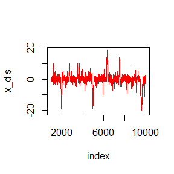

```r
set.seed(547)
# Choose normal distribution as a proposal distribution.
n<-1e4
x<-numeric(n)
x[1]<-rnorm(1,0,1) # sigma=1
k<-0
u<-runif(n)
for (l in 2:n) {
  xt<-x[l-1]
  y<-rnorm(1,xt)
  num<-dt(y,df=1)*dnorm(xt,mean=y)
  den<-dt(xt,df=1)*dnorm(y,mean=xt)

  alpha<-num/den
  if(u[l]<alpha)
    {x[l]<-y}
  else{
    x[l]<-xt
    k<-k+1
  }

}

index<-1001:n
x_dis<-x[index]
# discarding the first 1000 of the chain.
plot(index,x_dis,type="l",col="red")
```

```r
quan<-seq(0,1,.1)
decile<-qt(quan,df=1)
decile_simulation<-quantile(x_dis,quan)
cbind(decile,decile_simulation)
```

```
##          decile decile_simulation
## 0%         -Inf     -21.186392235
## 10%  -3.0776835      -3.156963796
## 20%  -1.3763819      -1.363207928
## 30%  -0.7265425      -0.692411521
## 40%  -0.3249197      -0.315268664
## 50%   0.0000000       0.005195478
## 60%   0.3249197       0.304527889
## 70%   0.7265425       0.682371393
## 80%   1.3763819       1.278308752
## 90%   3.0776835       2.517858560
## 100%        Inf      18.610537705
```

```r
set.seed(254)
n<-1e4
chain_generating<-function(n,x1,sigma){
  x<-numeric(n)
  u<-runif(n)
  x[1]<-x1
  for (l in 2:n) {
  xt<-x[l-1]
  y<-rnorm(1,xt,sigma)
  num<-dt(y,df=1)*dnorm(xt,mean=y,sigma)
  den<-dt(xt,df=1)*dnorm(y,mean=xt,sigma)

  alpha<-num/den
  if(u[l]<alpha)
    {x[l]<-y}
  else{
    x[l]<-xt
  }

  }
  x # return the chain
}
# chain-generating is a function to generate a chain by m-h sampler.

n.chain<-4
# number of chains.
x0<-c(-4,-1,1,4)
n<-1e4
data<-matrix(0,nrow=n.chain,ncol = n)
data[1,]<-chain_generating(n,x0[1],1)
data[2,]<-chain_generating(n,x0[2],1)
data[3,]<-chain_generating(n,x0[3],1)
data[4,]<-chain_generating(n,x0[4],1)
```

```r
psi<-t(apply(data, 1, cumsum))
for (i in 1:4) {
  psi[i,]<-psi[i,]/1:n
}



GR<-function(psi,n){
  psi<-as.matrix(psi)
  psirow.means<-rowMeans(psi)
  W<-mean(apply(psi, 1, "var"))
  v.hat<-(n-1)*W/n+var(psirow.means)
  R.hat<-v.hat/W
  R.hat
}
n<-1e4
rhat <- rep(0, n)
b<-1e3
#for (j in (b+1):n)
#        rhat[j] <- GR(psi[,1:j],n)
#    plot(x=(b+1):n,y=rhat[(b+1):n], type="l", xlab="index", ylab="R.hat",col="blue")
# we discard the first 1000 and plot since index=1001
#    abline(h=1.2, lty=2)
```

```r
# we need more than 3000 times until rhat<1.2.
# rhat_dis<-rhat[b+1:n]
# min(which(rhat_dis<1.2))+b
```

```r
#par(mfrow=c(2,2))
#for (i in 1:4) {
#  xi<-data[i,]
#  plot(xi,type = "l",col="blue",ylim = c(-15,15))
#}
```

9.8

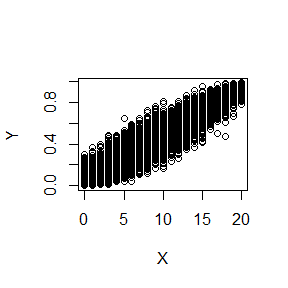

```r
set.seed(123)
n<-20
a<-1
b<-2
N<-1e4
data<-matrix(0,N,2)
data[1,]<-c(5,.5)
for (j in 2:N) {
  y<-data[j-1,2]
  data[j,1]<-rbinom(1,n,y)
  x<-data[j,1]
  data[j,2]<-rbeta(1,x+a,n-x+b)
}

b<-1e3+1 # discard the first 1000 of the chain.
chain<-data[b:N,]
plot(chain,xlab = "X",ylab = "Y")
```

```r
chain_generating<-function(x0,y0,N,n,a,b){
  data<-matrix(0,N,2)
  data[1,]<-c(x0,y0)
  for (j in 2:N) {
  y<-data[j-1,2]
  data[j,1]<-rbinom(1,n,y)
  x<-data[j,1]
  data[j,2]<-rbeta(1,x+a,n-x+b)
  }
  data

}
x0<-c(0,20,50,100)
y0<-c(.98,.6,.1,.01)
```

```r
library(stableGR)
```

```r
set.seed(5432)
N<-1020
a<-20
b<-30
n<-100
rhat<-numeric(N)
burn<-20
#for (j in burn+1:N) {
#  chain1<-chain_generating(x0[1],y0[1],j,n,a,b)
#  chain2<-chain_generating(x0[2],y0[2],j,n,a,b)
#  chain3<-chain_generating(x0[3],y0[3],j,n,a,b)
#  chain4<-chain_generating(x0[4],y0[4],j,n,a,b)
#  data<-list(chain1,chain2,chain3,chain4)
#  rhat[j]<-stable.GR(data,multivariate = TRUE,mapping = "maxeigen")$mpsrf

#}

#x<-100:N
#y<-rhat[100:N]
# it can be seen that even when N is not large enough,rhat is still very small.
#plot(100:N,rhat[100:N])
```

MLE Rearrange the data so that the ones less than 1 are in the front, and index the rearranged data as $\{t_i\},1\le i\le 10$, thus the MLE can be written as the following equation:

$$L(\lambda)\propto (e^{-\lambda})^3\Pi_1^{7}\lambda e^{-\lambda t_i}$$

The solution of MLE is :

$$\mathop{\arg\max}\limits_{\lambda} l(\lambda)=-3\lambda-\lambda \Sigma_{i=1}^{7}t_i+7\mathop{\log}(\lambda)$$

EM method: Let y be missing data.$y=(y_1,y_2,y_3)$ E-step:
$$l_o(\lambda,y)=10log\lambda -\lambda\sum_{i=1}^7t_i- \lambda \sum_{j=1}^3 y_i$$

$$E l_o(\lambda_0,y)=10log\lambda -\lambda\sum_{i=1}^7t_i- 3\lambda E(y|\lambda_0)\\
=10log\lambda -\lambda\sum_{i=1}^7t_i- 3\frac{\lambda_0+1}{\lambda_0}$$

M-step:
$$\lambda_1=\mathop{\arg\max}\limits_{\lambda} l(\lambda)=\frac{10}{\sum_{i=1}^7t_i+3\frac{\lambda_0+1}{\lambda_0}}\\
=\frac{10}{\beta+3\frac{\lambda_0+1}{\lambda_0}}$$
suppose $\hat{\lambda}=\lim_{n\to\infty} \lambda_n$,that is :
$$\hat{\lambda}=\frac{10}{\beta+3(\frac{\hat{\lambda+1}}{\hat{\lambda}})}$$
By simple algebra: $\hat{\lambda}=\frac{7}{\sum_{i=1}^7t_i+3}$,which is consistent with MLE.

```r
# lambda computed by MLE.
library(stats4)
obs <- c(0.54, 0.48, 0.33, 0.43, 1.00, 1.00, 0.91, 1.00, 0.21, 0.85)
mle.lam <- function(lambda=.3) {
  -(7*log(lambda) - lambda * sum(obs))
}
mle(mle.lam)@coef
```

```
##   lambda
## 1.037037
```

```r
iter<-1e2
tol <- .Machine$double.eps^0.5 #

lam <- 0.2 # the original value of lambda
lam.op <- lam + 1

for (i in 1:iter){
  lam <- 10/( 3/lam + sum(obs) )
  if (abs(lam - lam.op)/lam.op < tol){break}
  else{lam.op <- lam}

}

lam
```

```
## [1] 1.037037
```

```r
# the conclusion is the same as MLE
```

## HW9

11.3 a.

```r
kth_term<-function(a,k,d){
  norm.a<-norm(as.vector(a),type = "2")
  # norm of a vector
  e<-exp(lgamma((d+1)/2)+lgamma(k+(3/2))-lgamma(1+k+(d/2))-log(factorial(k))-k*log(2))
  coef<-(-1)^k
  (coef*e*norm.a^(2*k+2))/(2*k+1)*(2*k+2)
}

# for example, if we set a=(2,3),k=100,d=2.
kth_term(c(2,3),100,2)
```

```
## [1] 2.411445e-77
```

```r
k.sum<-function(a,K,d){
  a<-a
  k<-1:K
  d<-d
  sum(kth_term(a,k,d))
}
```

```r
a<-c(1,2)

d<-2
convergence<-numeric(5)
for (j in 20:25) {
  convergence[j-20]<-k.sum(a,j,d)
}
convergence
```

```
## [1] -4.635136 -4.635136 -4.635136 -4.635136 -4.635136
```

11.5

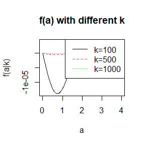

```r
# Firstly ,compute constants both sides, that is:
C1<-function(K){
  2*exp(lgamma(K/2)-lgamma((K-1)/2))/sqrt(pi*(K-1))
}
C2<-function(K){
  2*exp(lgamma((K+1)/2)-lgamma((K)/2))/sqrt(pi*K)
}
f.integ<-function(x,k){
  (1+x^2/k)^(-(k+1)/2)
}
# f.integ is the function which is integrated.

solve.a<-function(a,K){
  c.km1<-sqrt(a^2*(K-1)/(K-a^2))
  c.k<-sqrt(a^2*K/(K+1-a^2))
  inte.left<-integrate(f.integ,lower = 0,upper = c.km1,k<-K-1)$value
  inte.right<-integrate(f.integ,lower = 0,upper = c.k,k<-K)$value
  C1(K)*inte.left-C2(K)*inte.right
}
A.k<-numeric(25)
k<-c(4:25,100,500,1000)
for (j in 1:25) {
  if(k[j]<=7){
    up=sqrt(k[j]-.001)
  }else{
    up=2
  }
  A.k[j] <-unlist( uniroot(solve.a,lower=.0001,upper=up,K=k[j]))[1]}
# A.k is the root computed by uniroot.
# 11.4
k = c(4:25,100,500,1000)
S = function(a,k){
 ck = sqrt(a^2*k/(k+1-a^2))
 pt(ck,df=k,lower.tail=FALSE)
}

f = function(a,k){S(a,k)-S(a,k-1)}
#curve(f(x),xlim = c(0,sqrt(k)))
a <- seq(0, 4, by=0.01)
plot(a, f(a, k[23]), lty=1, col=1, type="l", xlim=c(0, 4), xlab="a", ylab="f(a|k)", main="f(a) with different k")
lines(a, f(a, k[24]), xlim = c(0, 4), lty=2, col=2)
lines(a, f(a, k[25]), xlim = c(0, 4), lty=3, col=3)
legend("topright", legend=c("k=100", "k=500", "k=1000"), col=1:3,lty=1:3)
```

```r
solve = function(k){
  output = uniroot(function(a){S(a,k)-S(a,k-1)},lower=1,upper=2)
  output$root
}

root = matrix(0,2,sum(lengths(k)))

for (i in 1:sum(lengths(k))){
  root[2,i]=round(solve(k[i]),4)
}

root[1,] = k
rownames(root) = c('k','A(k)')

# compare with 11.4
Ak<-root[2,]
index<-c(4:25,100,500,1000)
df<-data.frame(index,Ak,A.k)
# Ak is computed in 11.4, df is the dataframe to compare Ak and A.k

df
```

```
##    index     Ak      A.k
## 1      4 1.4921 1.492103
## 2      5 1.5336 1.533548
## 3      6 1.5627 1.562768
## 4      7 1.5844 1.584421
## 5      8 1.6012 1.601185
## 6      9 1.6145 1.614521
## 7     10 1.6254 1.625390
## 8     11 1.6344 1.634419
## 9     12 1.6420 1.642038
## 10    13 1.6486 1.648554
## 11    14 1.6542 1.654190
## 12    15 1.6591 1.659114
## 13    16 1.6635 1.663452
## 14    17 1.6673 1.667304
## 15    18 1.6707 1.670745
## 16    19 1.6738 1.673840
## 17    20 1.6766 1.676637
## 18    21 1.6792 1.679178
## 19    22 1.6815 1.681496
## 20    23 1.6836 1.683620
## 21    24 1.6856 1.685572
## 22    25 1.6874 1.687373
## 23   100 1.7206 1.720608
## 24   500 1.7298 1.729755
## 25  1000 1.7309 1.730907
```

## HW10

EX.1 Q： Why are the following two invocations of lapply() equivalent?

trims <- c(0, 0.1, 0.2, 0.5) x <- rcauchy(100) lapply(trims, function(trim) mean(x, trim = trim)) lapply(trims, mean, x = x)

trims is a parameter of mean, the first code to trims as a function of the parameters, the output of this function is the corresponding trim of the derived mean, that is, each element of trims into the mean. The second code, which takes mean as a function, directly uses lapply to match the elements in trims according to their positions, and the output values of the two methods are the same.

EX.5 For each model in the previous two exercises, extract R2 using the function below. rsq <- function(mod) summary(mod)$r.squared

3

```r
formulas <- list(
  mpg ~ disp,
  mpg ~ I(1 / disp),
  mpg ~ disp + wt,
  mpg ~ I(1 / disp) + wt
)

reg.la <- lapply(formulas, function(x) {lm(formula = x, mtcars)})



reg.lp <- vector("list", 4)
for (i in seq_along(formulas)){
  reg.lp[[i]] <- lm(formulas[[i]], data = mtcars)
}
```

4

```r
bootstraps <- lapply(1:10, function(i) {
  rows <- sample(1:nrow(mtcars), rep = TRUE)
  mtcars[rows, ]
})


regla.bs <- lapply(bootstraps, lm, formula = mpg ~ disp)

reglp.bs <- vector("list", 10)
for (i in seq_along(bootstraps)){
  reglp.bs[[i]] <- lm(mpg ~ disp,  bootstraps[[i]])
}
```

```r
# exercise3：
rsq <- function(mod) summary(mod)$r.squared
sapply(reg.la, rsq)
```

```
## [1] 0.7183433 0.8596865 0.7809306 0.8838038
```

```r
sapply(reg.lp, rsq)
```

```
## [1] 0.7183433 0.8596865 0.7809306 0.8838038
```

```r
# exercise4
sapply(regla.bs, rsq)
```

```
##  [1] 0.7165010 0.7876950 0.7550515 0.6547705 0.8149094 0.8078409 0.6831916
##  [8] 0.7467088 0.8069996 0.7106641
```

```r
sapply(reglp.bs,rsq)
```

```
##  [1] 0.7165010 0.7876950 0.7550515 0.6547705 0.8149094 0.8078409 0.6831916
##  [8] 0.7467088 0.8069996 0.7106641
```

exercise1 page213 Use vapply() to: a) Compute the standard deviation of every column in a numeric data frame. b) Compute the standard deviation of every numeric column in a mixed data frame. (Hint: you’ll need to use vapply() twice.)

```r
set.seed(225)
x<-rnorm(100,0,1)
y<-rpois(100,10)
data<-data.frame(x,y)

vapply(data, sd,numeric(1))
```

```
##        x        y
## 1.054800 3.156907
```

```r
z<-"a"
data1<-data.frame(x,y,z)
vapply(data1[vapply(data1, is.numeric, logical(1))],
       sd,
       numeric(1))
```

```
##        x        y
## 1.054800 3.156907
```

```r
# The internal vapply finds the columns in data1 that are numeric, and the external vapply finds the sd for the numeric columns.
```

## HW11

```r
library(Rcpp)
#  original value of x is specified
cppFunction('NumericMatrix RcppGibbs(int N, int n,int a, int b ) {

    int i;
    double yc;
    NumericMatrix mat(N, 2);
    mat(0,0)=5;
    mat(0,1)=.5;

    double x, y;

    for (i=1; i<N; i++) {

        yc=mat(i-1,1) ;
    x=R::rbinom(n,yc);
    y=R::rbeta(x+a,n-x+b);
        mat(i,0) = x;
        mat(i,1) = y;

    }

    return mat;
}')
```

```r
# sample using gibbs
Rgibbs<-function(N,n,a,b){
  data<-matrix(0,N,2)
  data[1,]<-c(5,.5)
  for (j in 2:N) {
  y<-data[j-1,2]
  data[j,1]<-rbinom(1,n,y)
  x<-data[j,1]
  data[j,2]<-rbeta(1,x+a,n-x+b)
  }
  data

}
```

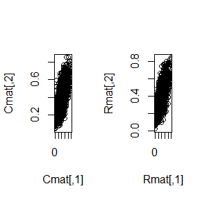

```r
set.seed(1578)
N<-2000
n<-10
a<-4
b<-6
Rmat<-Rgibbs(N,n,a,b)  # The random number matrix by r function.
Cmat<-RcppGibbs(N,n,a,b)# by Cpp function
par(mfrow=c(1,2))
plot(Cmat)
plot(Rmat)
```

qq plot Draw qqplot for each of the two components separately

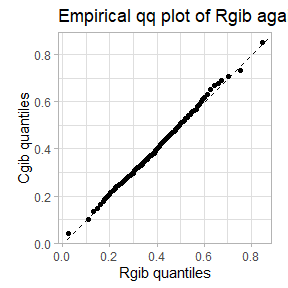

```r
library(ggplot2)
gg_qq_empirical <- function(a, b, quantiles = seq(0, 1, 0.01))
{
  a_lab <- deparse(substitute(a))
  if(missing(b)) {
    b <- rnorm(length(a), mean(a), sd(a))
    b_lab <- "normal distribution"
  }
  else b_lab <- deparse(substitute(b))

  ggplot(mapping = aes(x = quantile(a, quantiles),
                       y = quantile(b, quantiles))) +
    geom_point() +
    geom_abline(aes(slope = 1, intercept = 0), linetype = 2) +
    labs(x = paste(deparse(substitute(a)), "quantiles"),
         y = paste(deparse(substitute(b)), "quantiles"),
         title = paste("Empirical qq plot of", a_lab, "against", b_lab))
}
Rgib<-Rmat[,2]
Cgib<-Cmat[,2]

qq <- gg_qq_empirical(Rgib, Cgib)
qq + theme_light() + coord_equal()
```

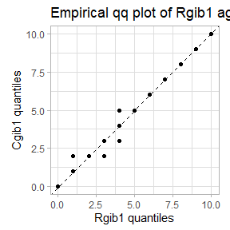

```r
Rgib1<-Rmat[,1]
Cgib1<-Cmat[,1]
qq1 <- gg_qq_empirical(Rgib1, Cgib1)
qq1 + theme_light() + coord_equal()
```

```r
# library(microbenchmark)
#ts <- microbenchmark(Rgib=Rgibbs(N,n,a,b),Cppgib=RcppGibbs(N,n,a,b))

#summary(ts)[,c(1,3,5,6)]
# rcpp's performace is better
```

```r
# Increase N Again compare the computational speed.
#N<-1e4
#ts <- microbenchmark(Rgib=Rgibbs(N,n,a,b),Cppgib=RcppGibbs(N,n,a,b))

#summary(ts)[,c(1,3,5,6)]
```